# Penguin Classification

Joan Balaguer, Jaume Adrover

2023-12-08

## 0. Introduction

In this assignment, our goal is to find out as many possible ways to group penguin according to different features, such as bill length or mass weight.

We’ll accomplish such task by using different clustering methods. These clustering methods will be grouped in hierarchical and partitioning ones.

## 1. Exploratory data analysis

First of all, let’s load our data and show a little summary, along with the head function to display few rows.

```r
data <- read.csv("penguindata.csv")
head(data)
```

```
##   X bill_length_mm bill_depth_mm flipper_length_mm body_mass_g    sex year
## 1 1           39.1          18.7               181        3750   male 2007
## 2 2           39.5          17.4               186        3800 female 2007
## 3 3           40.3          18.0               195        3250 female 2007
## 4 4             NA            NA                NA          NA   <NA> 2007
## 5 5           36.7          19.3               193        3450 female 2007
## 6 6           39.3          20.6               190        3650   male 2007
```

```r
summary(data)
```

```
##        X          bill_length_mm  bill_depth_mm   flipper_length_mm
##  Min.   :  1.00   Min.   :32.10   Min.   :13.10   Min.   :172.0
##  1st Qu.: 86.75   1st Qu.:39.23   1st Qu.:15.60   1st Qu.:190.0
##  Median :172.50   Median :44.45   Median :17.30   Median :197.0
##  Mean   :172.50   Mean   :43.92   Mean   :17.15   Mean   :200.9
##  3rd Qu.:258.25   3rd Qu.:48.50   3rd Qu.:18.70   3rd Qu.:213.0
##  Max.   :344.00   Max.   :59.60   Max.   :21.50   Max.   :231.0
##                   NA's   :2       NA's   :2       NA's   :2
##   body_mass_g       sex                 year
##  Min.   :2700   Length:344         Min.   :2007
##  1st Qu.:3550   Class :character   1st Qu.:2007
##  Median :4050   Mode  :character   Median :2008
##  Mean   :4202                      Mean   :2008
##  3rd Qu.:4750                      3rd Qu.:2009
##  Max.   :6300                      Max.   :2009
##  NA's   :2
```

### 1.2 Plotting single data values

In this stage, we’re going to see how variables are built in our dataset so we can group in a better way.

#### 1.2.1 Bill depth

This numerical column expresses in millimeters how deep a penguin’s bill is. Let’s see its distribution:

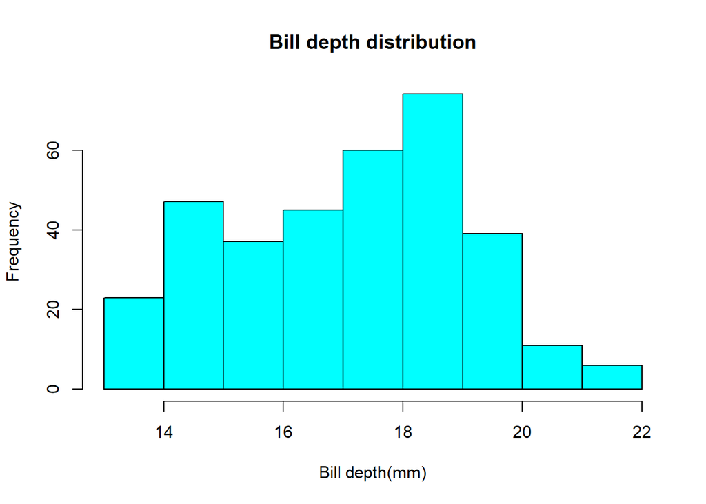

```r
hist(data$bill_depth_mm,main="Bill depth distribution",xlab="Bill depth(mm)",col="cyan")
```

#### 1.2.2 Bill length

This numerical column expresses in millimeters how long a penguin’s bill is. Let’s see its distribution:

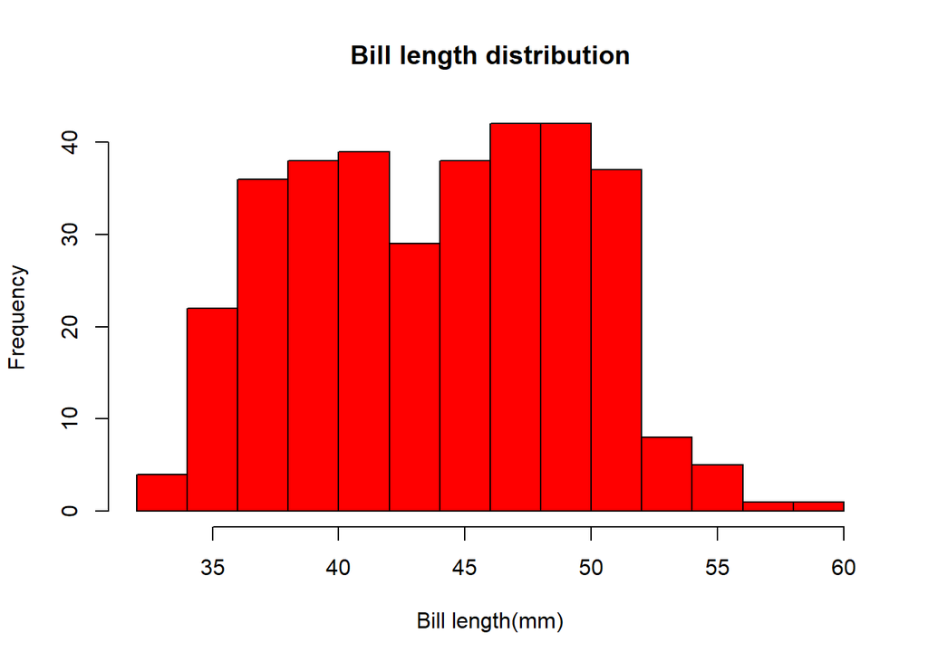

```r
hist(data$bill_length_mm,main="Bill length distribution",xlab="Bill length(mm)",col="red")
```

#### 1.2.3 Flipper length

Next, we’re going to look forward to how flipper length is distributed.

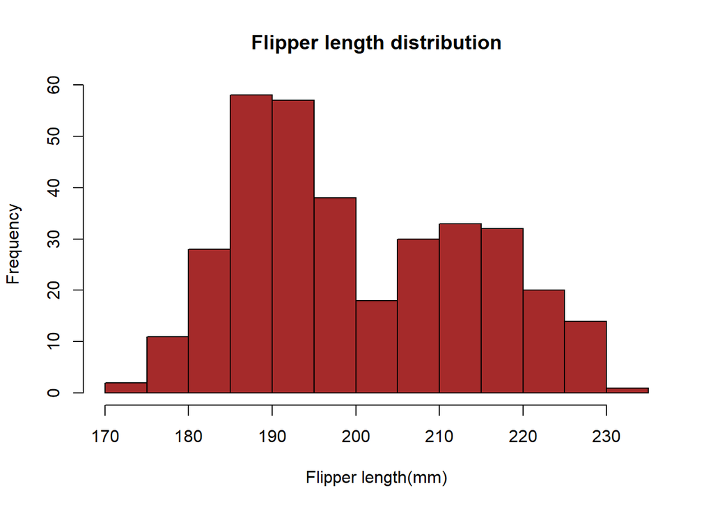

```r
hist(data$flipper_length_mm,main="Flipper length distribution",xlab="Flipper length(mm)",col="brown")
```

#### 1.2.4 Body mass

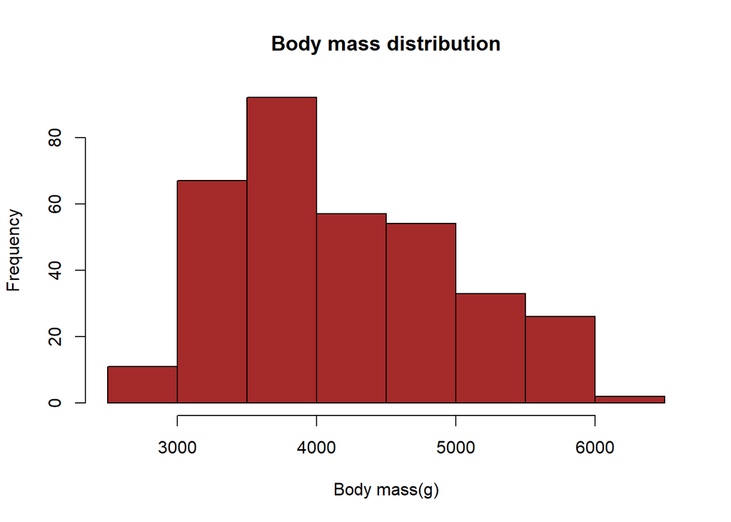

```r
hist(data$body_mass_g,main="Body mass distribution",xlab="Body mass(g)",col="brown")
```

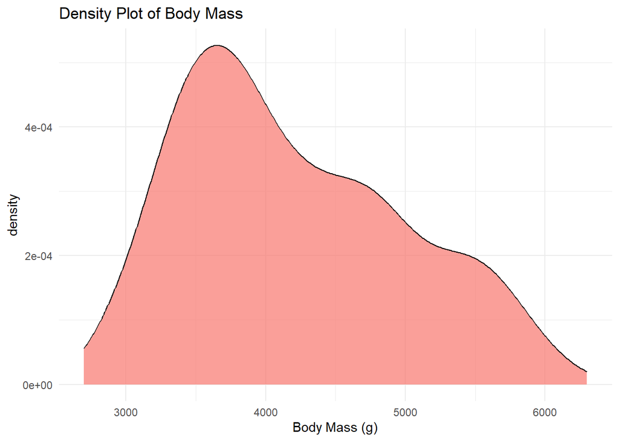

```r
ggplot(data, aes(x = body_mass_g, fill = "brown")) +
  geom_density(alpha = 0.7) +  # Add alpha for transparency
  labs(title = "Density Plot of Body Mass", x = "Body Mass (g)") +
  theme_minimal() +
  theme(legend.position = "none")
```

#### 1.2.5 Sex

Considering sex is a categorical column, we’ll show it with a pie chart and also a histogram. Let’s see % of each gender group

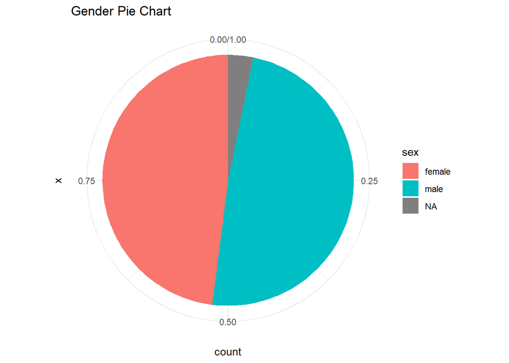

```r
# Gender Pie Chart
ggplot(data, aes(x = "", fill = sex)) +
  geom_bar(width = 1, position = "fill") +
  coord_polar(theta = "y") +
  labs(title = "Gender Pie Chart") +
  theme_minimal()
```

As we can clearly see, it seems that gender distribution is equal, without considering NA values that will be removed later. Let’s compare with a different point of view:

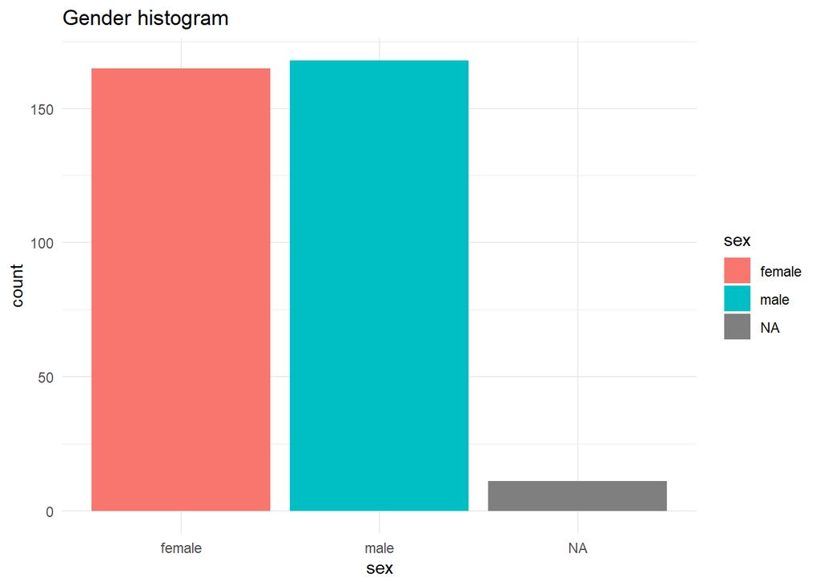

```r
# Gender Histogram
ggplot(data, aes(x = sex, fill = sex)) +
  geom_bar() +
  labs(title = "Gender histogram") +
  theme_minimal()
```

This different plot allows us to see that male count is slightly higher.

#### 1.2.6 Study year

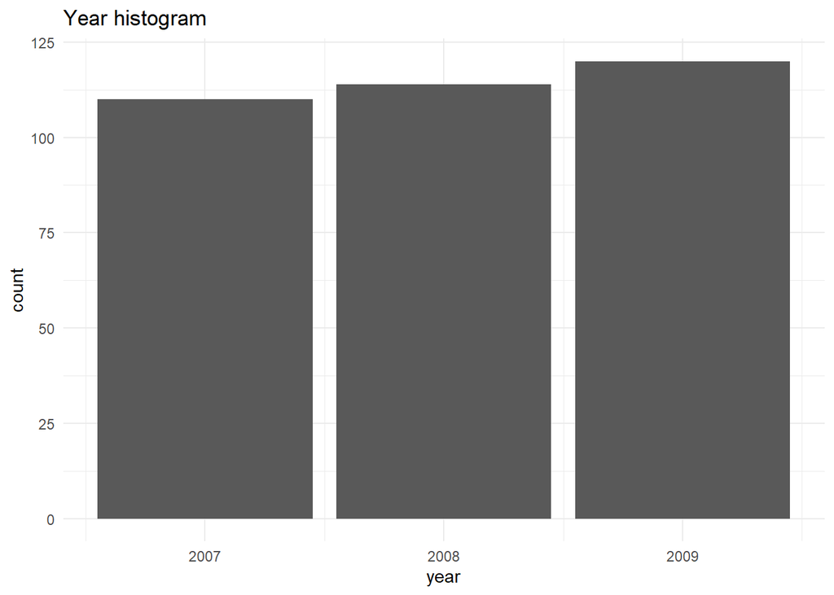

```r
# Year histogram
ggplot(data, aes(x = year, fill = year)) +
  geom_bar() +
  labs(title = "Year histogram") +
  theme_minimal()
```

## 2. Data cleaning

In this data cleaning phase, we’ll basically take care of these cases:

1. Missing values
2. Filter relevant data
3. Categorical columns
4. Data Scaling

### 2.1 Missing values

Let’s look for missing values with this function:

```r
na_summary_func <- function(data) {
  # NA values for column
  na_counts <- colSums(is.na(data))

  na_summary <- data.frame(Column = names(na_counts), NA_Count = na_counts)

  na_summary <- na_summary[na_summary$NA_Count > 0,]

  return(na_summary)
}
```

Let’s use it.

```r
na_summary_func(data)
```

```
##                              Column NA_Count
## bill_length_mm       bill_length_mm        2
## bill_depth_mm         bill_depth_mm        2
## flipper_length_mm flipper_length_mm        2
## body_mass_g             body_mass_g        2
## sex                             sex       11
```

As we can clearly see, there are 11 rows where sex is NA and other numeric values in 2 rows. Considering we can’t replace sex, we are going to remove all rows where there is any NA value.

If we only had missing values in numerical columns one choice would be to replace them for the mean.

```r
clean_data <- na.omit(data)
```

Let’s check if it worked.

```r
na_summary_func(clean_data)
```

```
## [1] Column   NA_Count
## <0 rows> (or 0-length row.names)
```

We have 0 rows with missing values, great.

### 2.2 Filter relevant data

As we have seen, the only non desired column would be X, as it acts as an unique identifier for each row.

```r
clean_data <- subset(clean_data, select = -X)
```

### 2.3 Categorical columns

We could consider year a categorical column but it is formatted as a numerical one son we’ll only focus on sex one.

We are going to replcae unique values like this:

1- Male: 1 2- Female: 0

```r
clean_data$sex <- ifelse(clean_data$sex=="male",1,0)
```

Let’s check:

```r
head(clean_data)
```

```
##   bill_length_mm bill_depth_mm flipper_length_mm body_mass_g sex year
## 1           39.1          18.7               181        3750   1 2007
## 2           39.5          17.4               186        3800   0 2007
## 3           40.3          18.0               195        3250   0 2007
## 5           36.7          19.3               193        3450   0 2007
## 6           39.3          20.6               190        3650   1 2007
## 7           38.9          17.8               181        3625   0 2007
```

### 2.4 Data scaling

In this final data preparation step we’re going to normalize values between 0 and 1.

We’ll use caret built-in function preProcess that uses this formula:

$$x' = \frac{{x -
\text{min}(X)}}{{\text{max}(X) - \text{min}(X)}}$$

Result from this formula meets the following condition:

$$x' \in [0,1]$$

Let’s scale our values:

```r
preprocess_model <- preProcess(clean_data, method = "range")

# Scale whole dataframe
df_scaled <- predict(preprocess_model, newdata = clean_data)

summary(df_scaled)
```

```
##  bill_length_mm   bill_depth_mm    flipper_length_mm  body_mass_g
##  Min.   :0.0000   Min.   :0.0000   Min.   :0.0000    Min.   :0.0000
##  1st Qu.:0.2691   1st Qu.:0.2976   1st Qu.:0.3051    1st Qu.:0.2361
##  Median :0.4509   Median :0.5000   Median :0.4237    Median :0.3750
##  Mean   :0.4325   Mean   :0.4839   Mean   :0.4910    Mean   :0.4186
##  3rd Qu.:0.6000   3rd Qu.:0.6667   3rd Qu.:0.6949    3rd Qu.:0.5764
##  Max.   :1.0000   Max.   :1.0000   Max.   :1.0000    Max.   :1.0000
##       sex              year
##  Min.   :0.0000   Min.   :0.000
##  1st Qu.:0.0000   1st Qu.:0.000
##  Median :1.0000   Median :0.500
##  Mean   :0.5045   Mean   :0.521
##  3rd Qu.:1.0000   3rd Qu.:1.000
##  Max.   :1.0000   Max.   :1.000
```

## 3. Clustering

### 3.1 Plotting relationship between variables

Now, we’re going to consider different variables pair so we can choose which combinations fit the best to group our beloved penguins. We’ll plot different ones and choose what we think are the best pairs. We have to exclude year as we think it’s not a great grouping variable as it’s not implicit en penguin features. Our goal would be to group new penguins into clusters and study year couldn’t be included.

#### 3.1.1 Sex

Sex vs body mass:

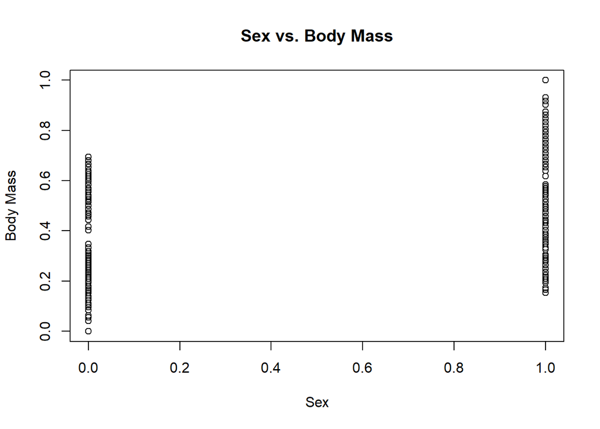

```r
plot(df_scaled$sex, df_scaled$body_mass_g,
     xlab = "Sex",
     ylab = "Body Mass",
     main = "Sex vs. Body Mass")
```

We can clearly see that we could pull apart 4 different groups and that male gender is associated with a higher body mass.

Sex vs Flipper length:

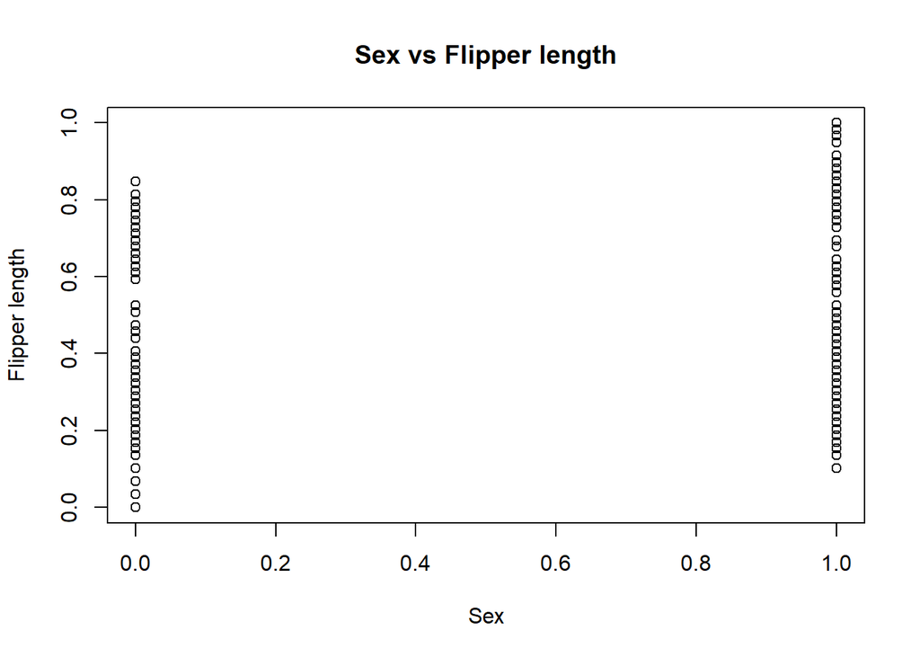

```r
plot(df_scaled$sex, df_scaled$flipper_length_mm,
     xlab = "Sex",
     ylab = "Flipper length",
     main = "Sex vs Flipper length")
```

This could be a possible grouping criteria, it seems male penguins have longer flippers.

Sex vs bill length:

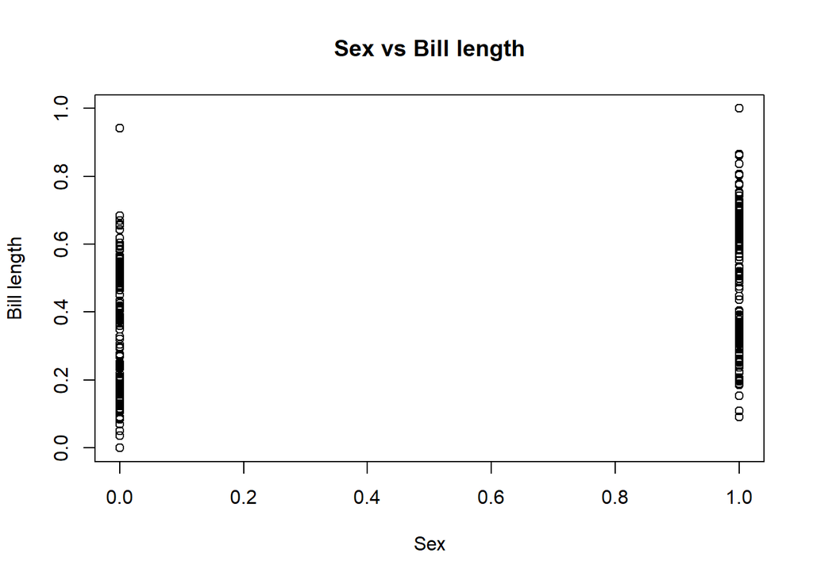

```r
plot(df_scaled$sex, df_scaled$bill_length_mm,
     xlab = "Sex",
     ylab = "Bill length",
     main = "Sex vs Bill length")
```

Sex vs bill depth:

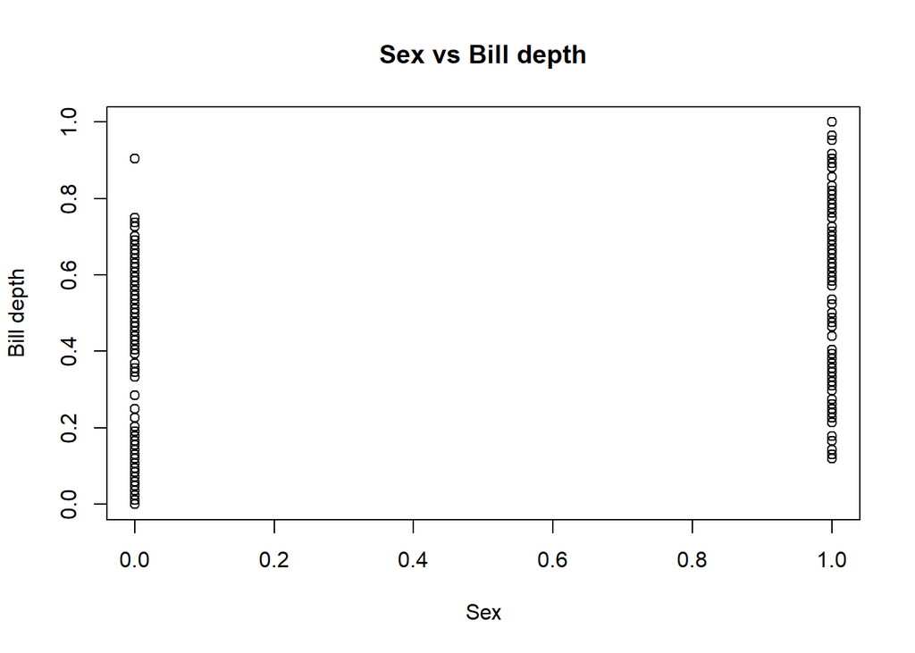

```r
plot(df_scaled$sex, df_scaled$bill_depth_mm,
     xlab = "Sex",
     ylab = "Bill depth",
     main = "Sex vs Bill depth")
```

#### 3.1.2 Bill length

Bill length vs Body Mass:

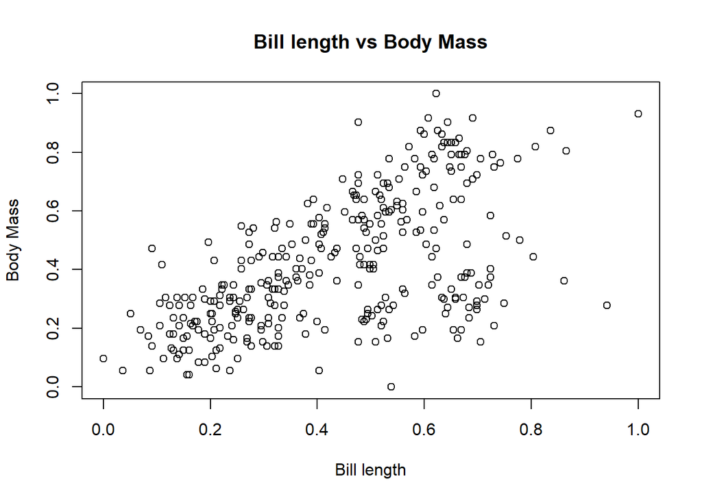

```r
plot(df_scaled$bill_length_mm, df_scaled$body_mass_g,
     xlab = "Bill length",
     ylab = "Body Mass",
     main = "Bill length vs Body Mass")
```

Bill length vs Flipper length:

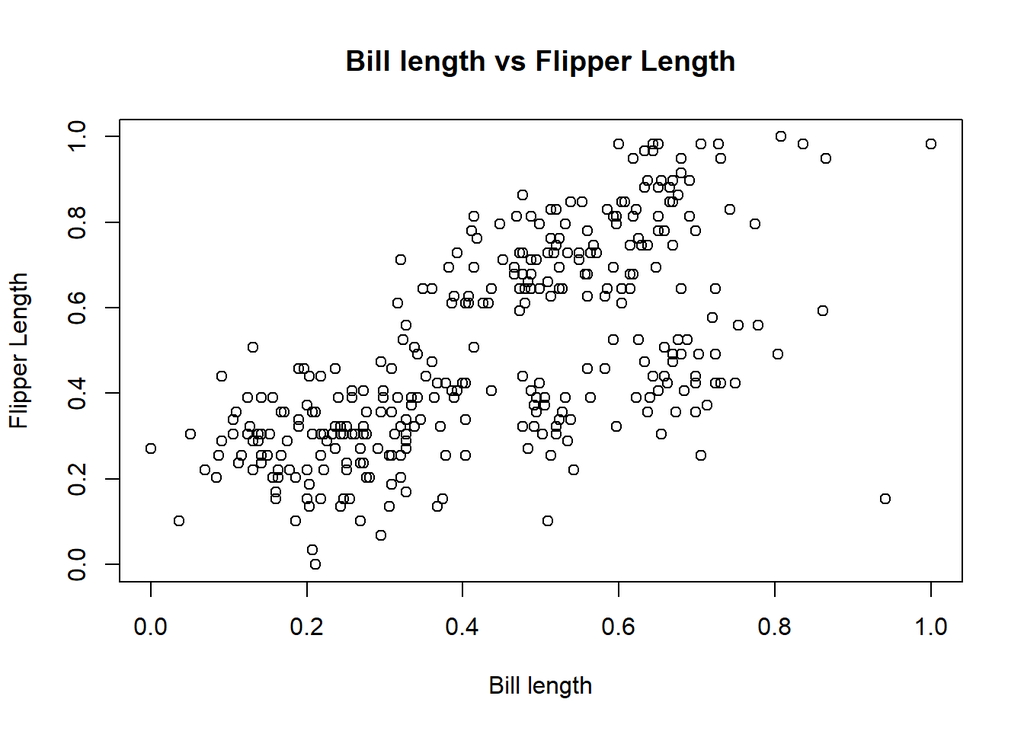

```r
plot(df_scaled$bill_length_mm, df_scaled$flipper_length_mm,
     xlab = "Bill length",
     ylab = "Flipper Length",
     main = "Bill length vs Flipper Length")
```

Bill length vs Bill depth:

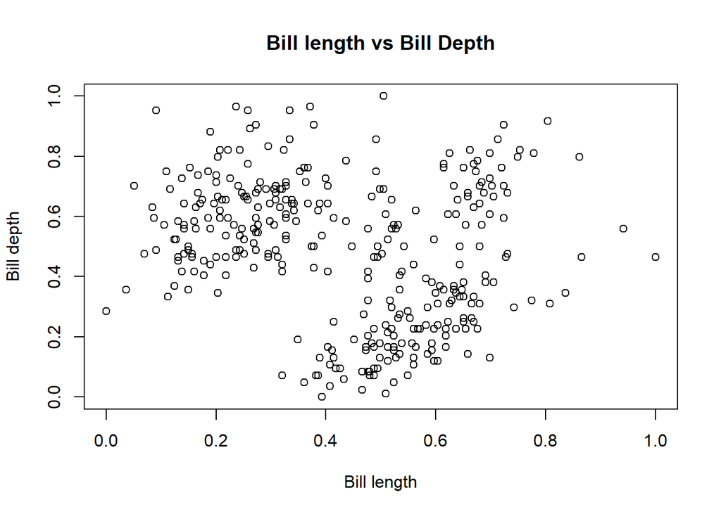

```r
plot(df_scaled$bill_length_mm, df_scaled$bill_depth_mm,
     xlab = "Bill length",
     ylab = "Bill depth",
     main = "Bill length vs Bill Depth")
```

#### 3.1.3 Bill depth

Bill depth vs Body Mass:

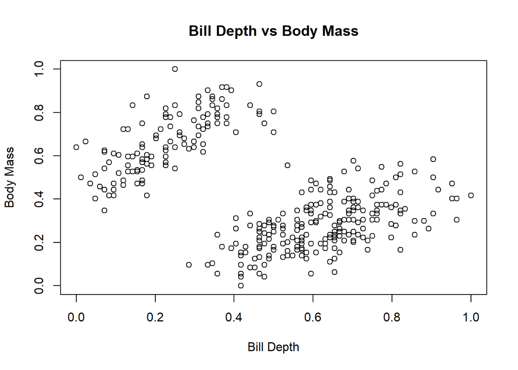

```r
plot(df_scaled$bill_depth_mm, df_scaled$body_mass_g,
     xlab = "Bill Depth",
     ylab = "Body Mass",
     main = "Bill Depth vs Body Mass")
```

Bill depth vs Flipper Length:

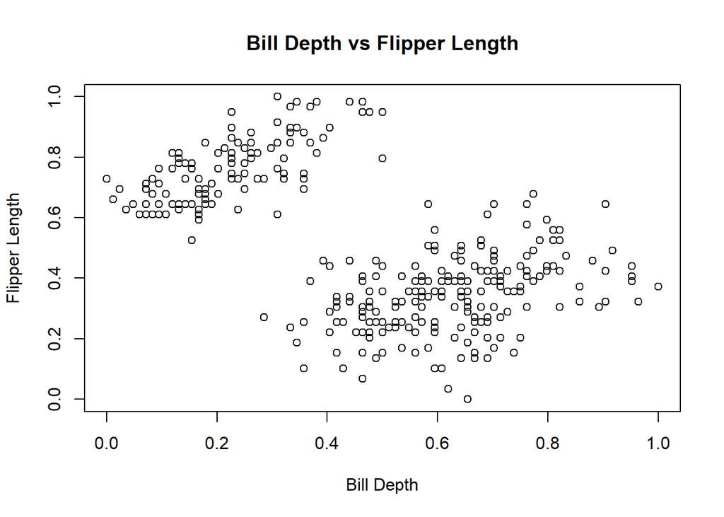

```r
plot(df_scaled$bill_depth_mm, df_scaled$flipper_length_mm,
     xlab = "Bill Depth",
     ylab = "Flipper Length",
     main = "Bill Depth vs Flipper Length")
```

#### 3.1.4 Flipper length

Flipper length vs Body Mass

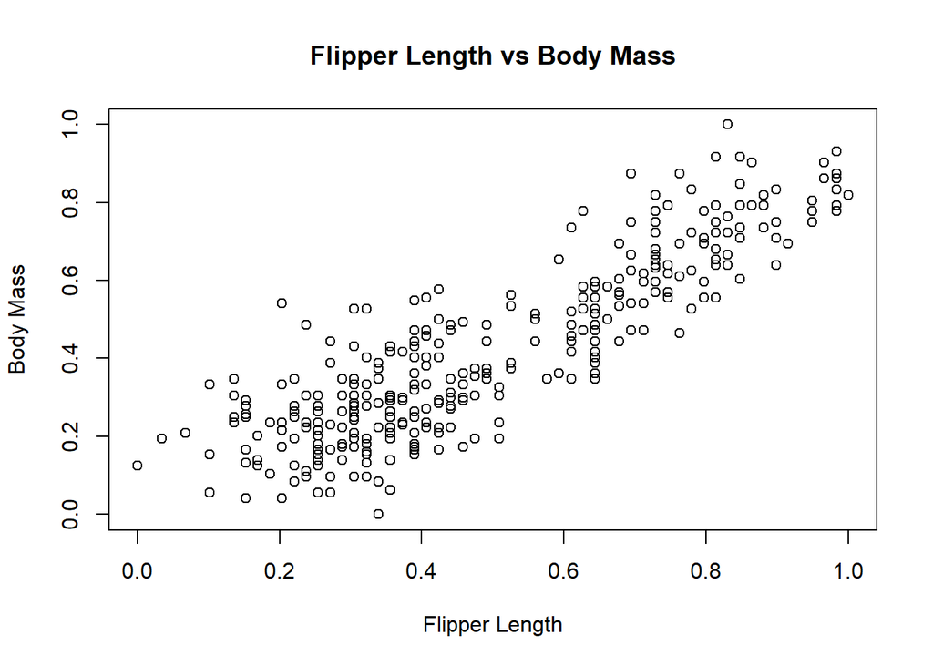

```r
plot(df_scaled$flipper_length_mm, df_scaled$body_mass_g,
     xlab = "Flipper Length",
     ylab = "Body Mass",
     main = "Flipper Length vs Body Mass")
```

#### 3.1.5 Chosen combinations

Final list is:

According to *sex*:

1. Sex vs Body Mass
2. Sex vs Bill Depth
3. Sex vs Bill Length
4. Sex vs Flipper Length

According to *flipper length*:

1. Flipper Length vs Bill Length
2. Flipper Length vs Bill Depth
3. Flipper Length vs Body Mass

According to *bill length*:

1. Bill Length vs Body Mass
2. Bill Length vs Bill Depth

These are going to be some of our final 2x variable combinations to cluster by.

### 3.2 Partitioning Clustering models

#### 3.2.1 K-means

First of all, we are going to make an agroupment, creating a clustering k-means model for each combination. Let’s define all necessary functions:

```r
# Function to create Cluster given k,nstart and specified columns
createCluster <- function(k_value,nstart_value,cols){
  set.seed(123)
  df = df_scaled[cols]

  # K-means
  kmeans_result <- kmeans(df, centers = k_value, nstart = nstart_value)

  # Cluster plotting
  kmeans_plot <-fviz_cluster(kmeans_result, data = df)

  return (list(result=kmeans_result,plot=kmeans_plot))
}

# Function to plot cluster means
cluster_means <-function(kmeans,cols){
  for (i in 1:nrow(kmeans)){
    cat("Cluster", i - 1, "->",cols[1],":", kmeans[i, cols[1]], ",", cols[2],":", kmeans[i, cols[2]], "\n")
  }
}
```

##### **Sex vs body_mass_g**

Let’s try with a k=3 model:

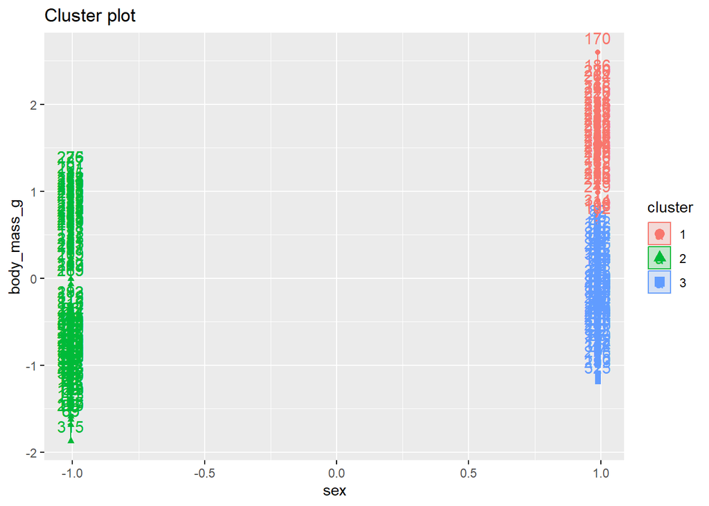

```r
cols=c("sex","body_mass_g")
cluster <- createCluster(3,25,cols)
cluster$plot
```

It kinda looks like there could be two groups in the left column, let’s increase k by 1.

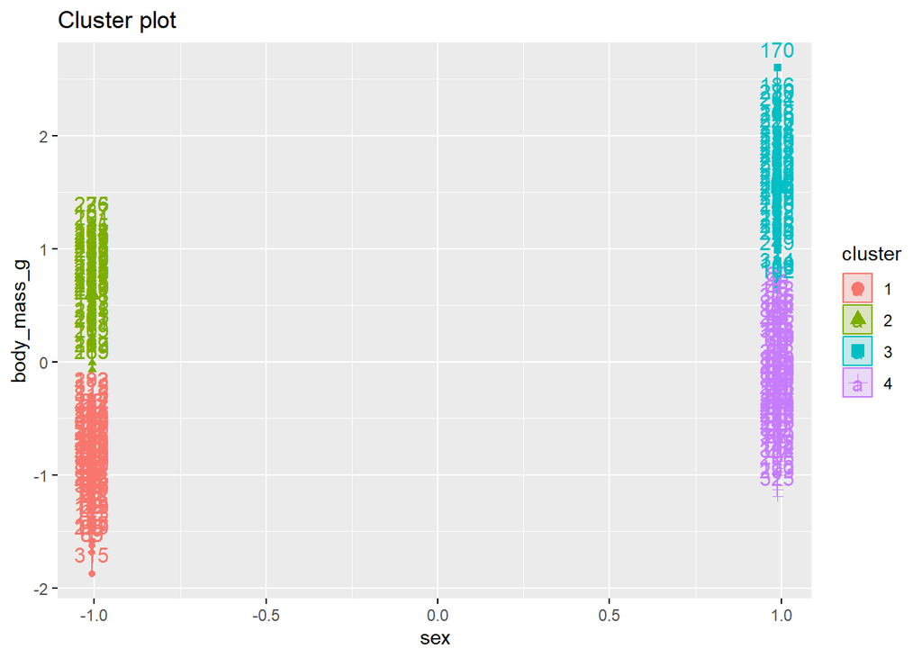

```r
cluster <- createCluster(4,25,cols)
cluster$plot
```

That looks much better, let’s see every cluster mean:

```r
# Show cluster means
cluster_means(cluster$result$centers,cols)
```

```
## Cluster 0 -> sex : 0 , body_mass_g : 0.1992471
## Cluster 1 -> sex : 0 , body_mass_g : 0.550886
## Cluster 2 -> sex : 1 , body_mass_g : 0.7642144
## Cluster 3 -> sex : 1 , body_mass_g : 0.357906
```

##### **Sex vs bill_depth_mm**

Let’s change our column choice now.

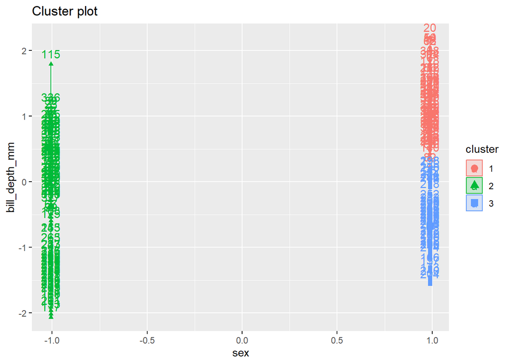

```r
cols=c("sex","bill_depth_mm")
cluster <- createCluster(3,25,cols)
cluster$plot
```

It seems that clusters are a little big, they keep lot of points, let’s try a bigger k value.

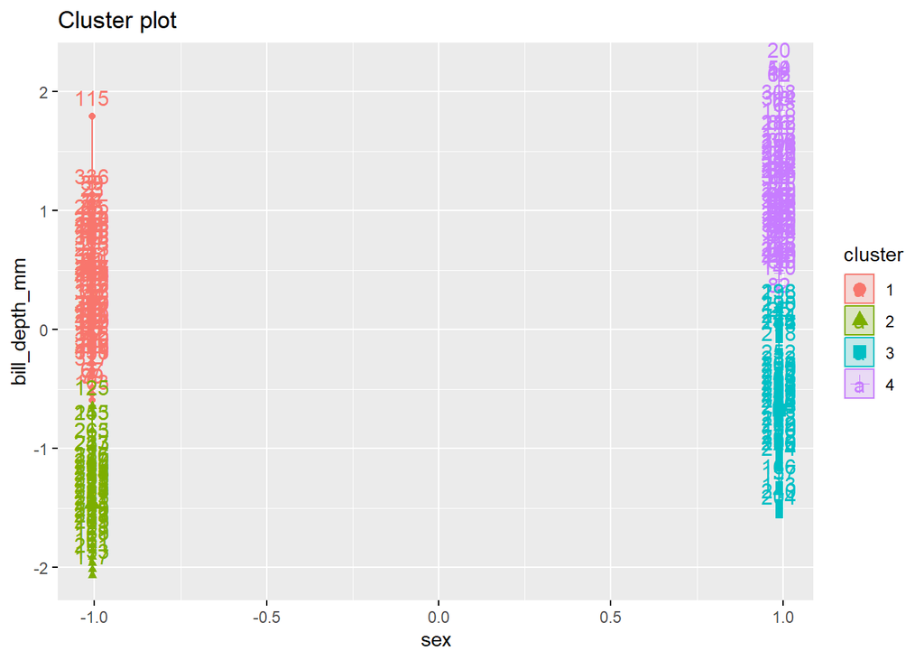

```r
cluster <- createCluster(4,25,cols)
cluster$plot
```

That looks much better, these could behave as 4 different groups:

1. Small depth bill,females(cluster 2)
2. Large depth bill,females(cluster 1)
3. Small depth bill,males(cluster 3)
4. Large depth bill,males(cluster 4)

And, given these grouping criteria, we could almost add a medium category to each gender, so we would have k=6:

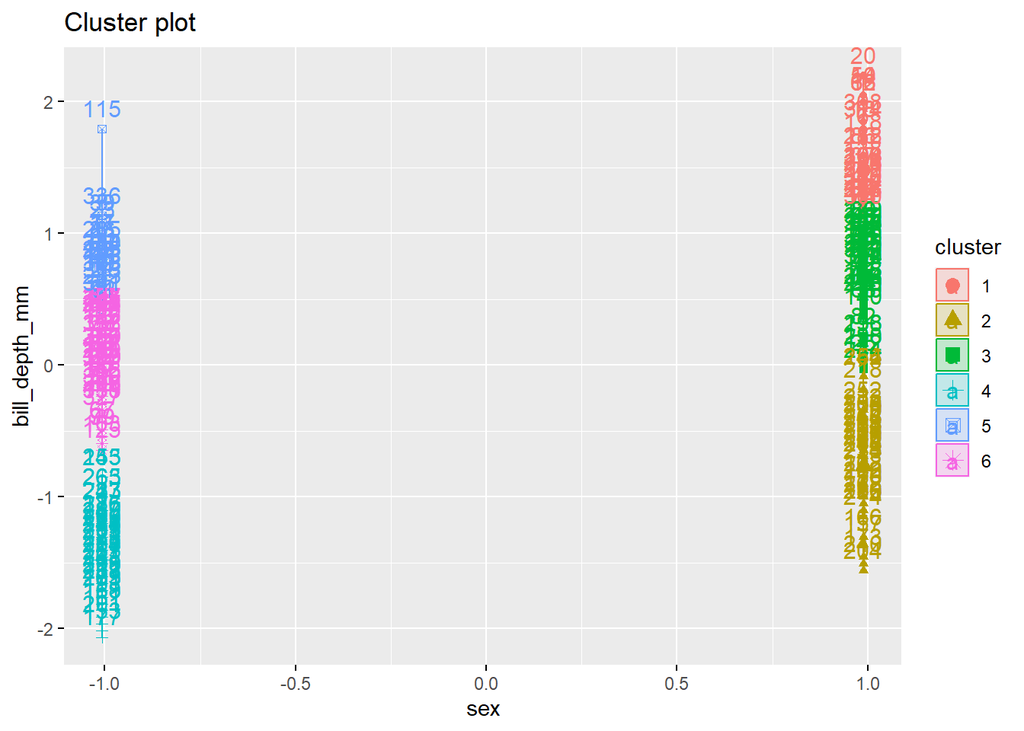

```r
cluster <- createCluster(6,25,cols)
cluster$plot
```

Then, we would have previous categories plus:

5. Medium depth bill, females
6. Medium depth bill, males

Let’s finally see every cluster mean:

```r
cluster_means(cluster$result$centers,cols)
```

```
## Cluster 0 -> sex : 1 , bill_depth_mm : 0.8310658
## Cluster 1 -> sex : 1 , bill_depth_mm : 0.3050847
## Cluster 2 -> sex : 1 , bill_depth_mm : 0.6405473
## Cluster 3 -> sex : 0 , bill_depth_mm : 0.1380145
## Cluster 4 -> sex : 0 , bill_depth_mm : 0.6629464
## Cluster 5 -> sex : 0 , bill_depth_mm : 0.4860039
```

That could be a nice grouping rule.

##### **Sex vs bill_length_mm**

Let’s apply the same grouping rule as the previous one. Let’s start with k=4.

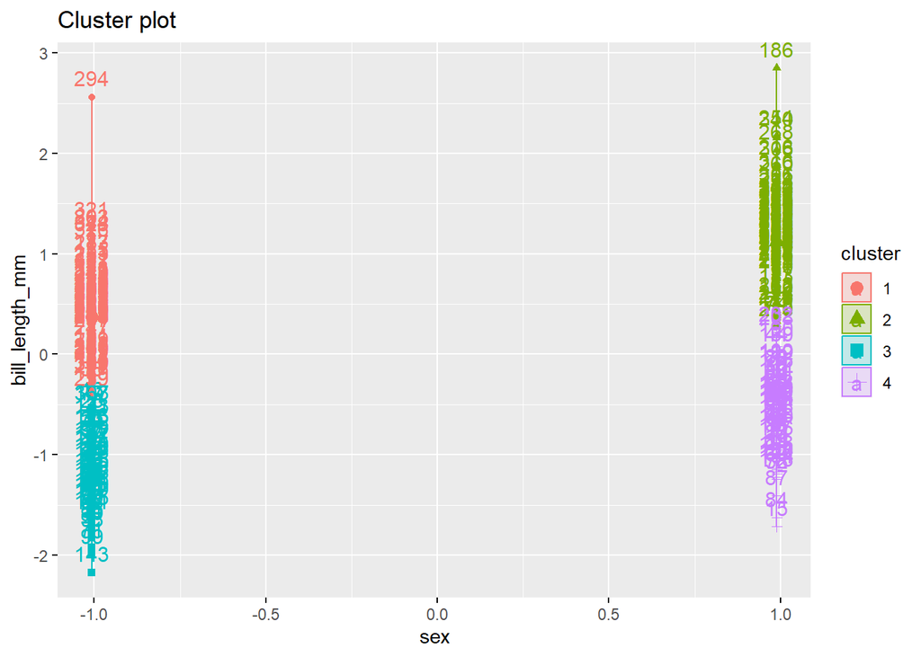

```r
cols=c("sex","bill_length_mm")
cluster <- createCluster(4,25,cols)
cluster$plot
```

We could say the same about this one, let’s add a medium category, so k=6

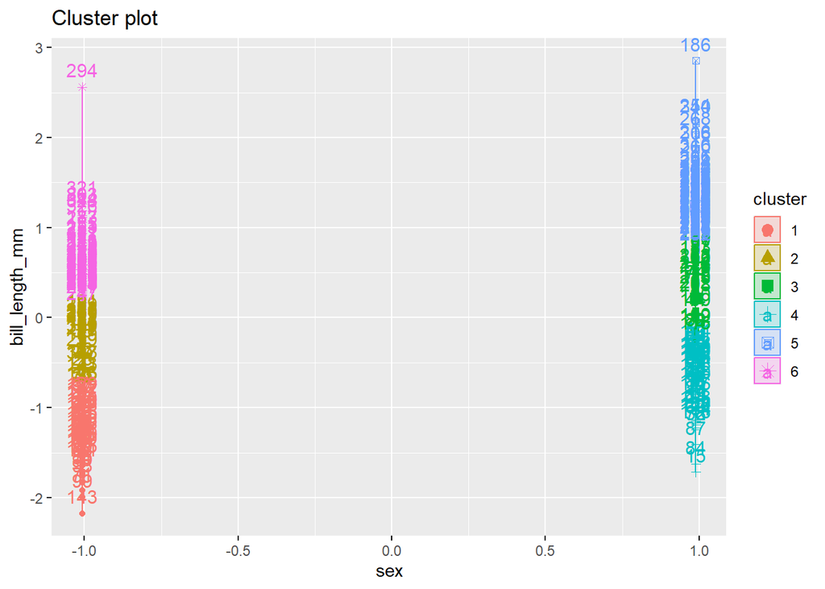

```r
cluster <- createCluster(6,25,cols)
cluster$plot
```

We now have 3 categories for each gender: small,medium and large long bills.

Let’s see every cluster mean:

```r
cluster_means(cluster$result$centers,cols)
```

```
## Cluster 0 -> sex : 0 , bill_length_mm : 0.1624037
## Cluster 1 -> sex : 0 , bill_length_mm : 0.3525253
## Cluster 2 -> sex : 1 , bill_length_mm : 0.4748822
## Cluster 3 -> sex : 1 , bill_length_mm : 0.2768405
## Cluster 4 -> sex : 1 , bill_length_mm : 0.679
## Cluster 5 -> sex : 0 , bill_length_mm : 0.5387013
```

That would also be a nice,similar grouping rule.

##### **Sex vs flipper_length_mm**

Considering flipper length is similar to previous columns, we’ll initially try with k=6.

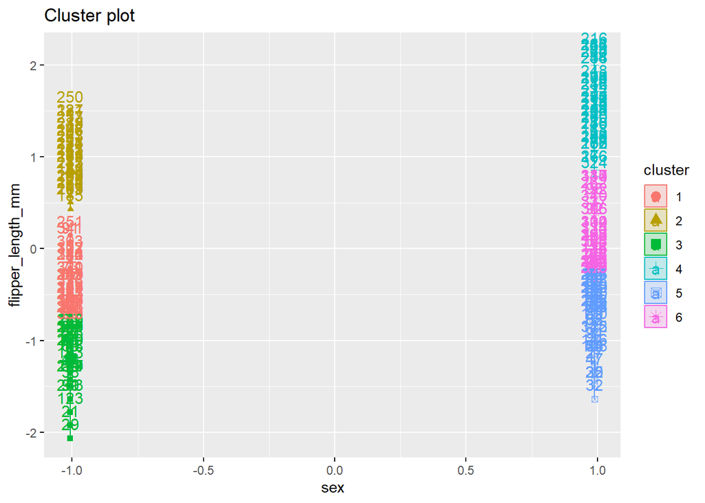

```r
cols=c("sex","flipper_length_mm")
cluster <- createCluster(6,25,cols)
cluster$plot
```

This is great, it works like the other ones. We have short, medium and large flipper for each gender.

Let’s see all cluster means:

```r
cluster_means(cluster$result$centers,cols)
```

```
## Cluster 0 -> sex : 0 , flipper_length_mm : 0.3639759
## Cluster 1 -> sex : 0 , flipper_length_mm : 0.6928338
## Cluster 2 -> sex : 0 , flipper_length_mm : 0.2033898
## Cluster 3 -> sex : 1 , flipper_length_mm : 0.8443503
## Cluster 4 -> sex : 1 , flipper_length_mm : 0.2967588
## Cluster 5 -> sex : 1 , flipper_length_mm : 0.4898637
```

##### **Bill_length_mm vs bill_depth_mm**

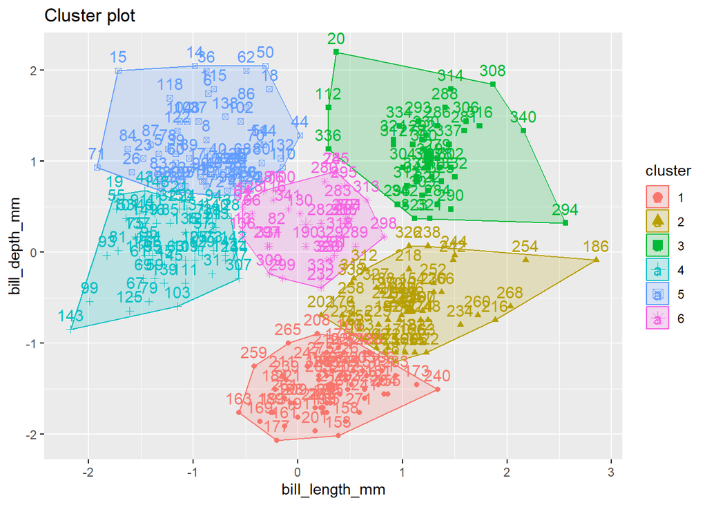

```r
cols=c("bill_length_mm","bill_depth_mm")
cluster <- createCluster(6,25,cols)
cluster$plot
```

We can see six different groups according to length or depth bill.

These are our final centroids:

```r
cluster_means(cluster$result$centers,cols)
```

```
## Cluster 0 -> bill_length_mm : 0.4946573 , bill_depth_mm : 0.1395604
## Cluster 1 -> bill_length_mm : 0.6441467 , bill_depth_mm : 0.3343776
## Cluster 2 -> bill_length_mm : 0.6824834 , bill_depth_mm : 0.731417
## Cluster 3 -> bill_length_mm : 0.1933333 , bill_depth_mm : 0.5016234
## Cluster 4 -> bill_length_mm : 0.2635262 , bill_depth_mm : 0.739899
## Cluster 5 -> bill_length_mm : 0.4475598 , bill_depth_mm : 0.5548246
```

#### 3.2.2 K-medoids

Now, let’s try another cluster partitioning model like k-medoids. In this one, each cluster is represented by one of the objects in the cluster. Main difference between k-means and this one is that this takes medoid as the point whose sum of dissimilarities is the lowest. In addition, this algorithm is less sensitive to outliers. Let’s define all needed functions:

```r
#Function for creating K-Medoids clusters
createKmedoids <- function(k_value,cols){
  set.seed(123)
  result <- pam(df_scaled[cols], k = k_value, diss = FALSE)
  plot <- fviz_cluster(result, data = df_scaled[cols])
  return (list(result=result,plot=plot))
}
#Function for plotting every algorithm Medoids
plotKmedoidsMeans <- function(k_medoids,cols){
    for (i in 1:nrow(k_medoids)){
    cat("Cluster", i - 1, "->",cols[1],":", k_medoids[i, cols[1]], ",", cols[2],":", k_medoids[i, cols[2]], "\n")
  }
}
```

We’re going to show some of the previous combinations to see if anything is different:

##### **Sex vs body_mass_g**

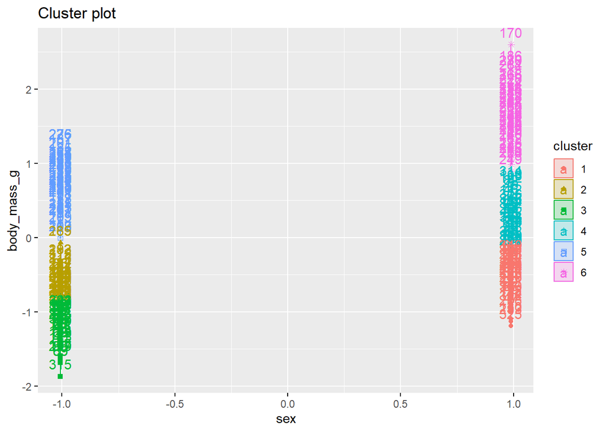

```r
cols <- c("sex","body_mass_g")
cluster <- createKmedoids(6,cols)
cluster$plot
```

As we can see, this algorithm is less sensitive to outliers because in the k-means one, distance to the left upper one was higher. Let’s see final medoids:

```r
plotKmedoidsMeans(cluster$result$medoids,cols)
```

```
## Cluster 0 -> sex : 1 , body_mass_g : 0.3055556
## Cluster 1 -> sex : 0 , body_mass_g : 0.2638889
## Cluster 2 -> sex : 0 , body_mass_g : 0.1388889
## Cluster 3 -> sex : 1 , body_mass_g : 0.4444444
## Cluster 4 -> sex : 0 , body_mass_g : 0.5555556
## Cluster 5 -> sex : 1 , body_mass_g : 0.7777778
```

##### **Sex vs bill_length_mm**

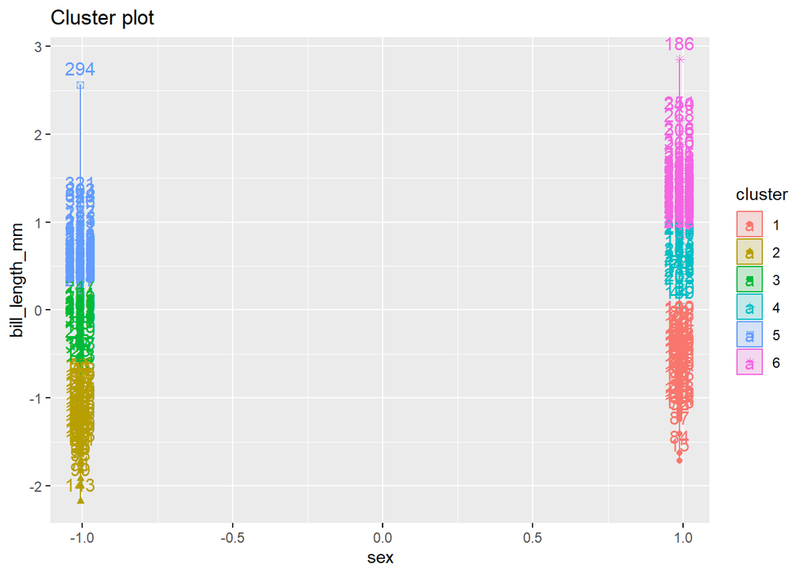

```r
cols <- c("sex","bill_length_mm")
cluster <- createKmedoids(6,cols)
cluster$plot
```

It’s similar to K-means but it seems outliers are closer.

Let’s see final medoids:

```r
plotKmedoidsMeans(cluster$result$medoids,cols)
```

```
## Cluster 0 -> sex : 1 , bill_length_mm : 0.3090909
## Cluster 1 -> sex : 0 , bill_length_mm : 0.1672727
## Cluster 2 -> sex : 0 , bill_length_mm : 0.3818182
## Cluster 3 -> sex : 1 , bill_length_mm : 0.5090909
## Cluster 4 -> sex : 0 , bill_length_mm : 0.5236364
## Cluster 5 -> sex : 1 , bill_length_mm : 0.6690909
```

We could classify into small,medium and large for each gender too.

##### **Bill_length_mm vs bill_depth_mm**

Let’s finally check if we can group for length and depth for each penguin bill.

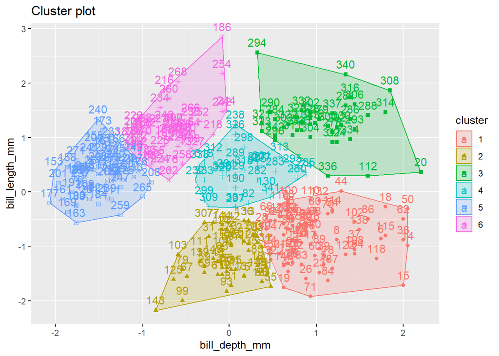

```r
cols <- c("bill_depth_mm","bill_length_mm")
cluster <- createKmedoids(6,cols)
cluster$plot
```

We can clearly see there are 6 different groups.

Let’s see final medoids:

```r
plotKmedoidsMeans(cluster$result$medoids,cols)
```

```
## Cluster 0 -> bill_depth_mm : 0.6904762 , bill_length_mm : 0.2763636
## Cluster 1 -> bill_depth_mm : 0.4642857 , bill_length_mm : 0.2
## Cluster 2 -> bill_depth_mm : 0.7142857 , bill_length_mm : 0.6836364
## Cluster 3 -> bill_depth_mm : 0.5238095 , bill_length_mm : 0.5127273
## Cluster 4 -> bill_depth_mm : 0.1309524 , bill_length_mm : 0.4981818
## Cluster 5 -> bill_depth_mm : 0.3214286 , bill_length_mm : 0.6290909
```

### 3.3 Hierarchical Clustering models

Let’s change way to group by, we’re going to use hierarchical clustering models now. We’re going to use a 50 size random sample:

```r
set.seed(123)
indices <- sample(1:dim(df_scaled)[1], 50)
penguin_sample <- df_scaled[indices,]
```

#### 3.3.1 Aglomertive clustering models (hclust)

Let’s focus on aglomerative models based in library **hclust**.

##### Complete linkage

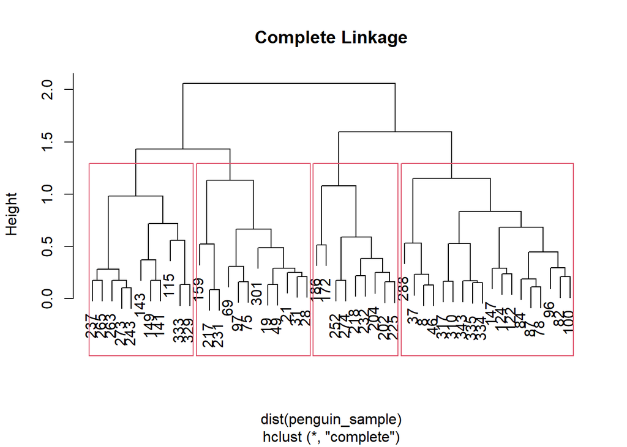

```r
set.seed(123)
# Complete Linkage
hc_complete <- hclust(dist(penguin_sample), method = "complete")
plot(hc_complete, main = "Complete Linkage")
rect.hclust(hc_complete,k=4)
```

```r
groups <- cutree(hc_complete,k=4)
print(groups)
```

```
## 186  19 202 317 124 310 237 252 343 159  96  97 265 204 333 143  31   8 329 263
##   1   2   1   3   3   3   4   1   3   2   3   2   4   1   4   4   2   3   4   4
## 218  84  87  49 149  37 115 274  28 141 232 172 225 301  75  78  82  69 147 217
##   1   3   3   2   4   3   4   1   2   4   1   1   1   2   2   3   3   2   3   2
## 335 288  46 334 231  21 122 100 273 243
##   3   3   3   3   2   2   3   3   4   4
```

We can see results in dendogram, with it’s bounding boxes and specified groups.

##### Single linkage

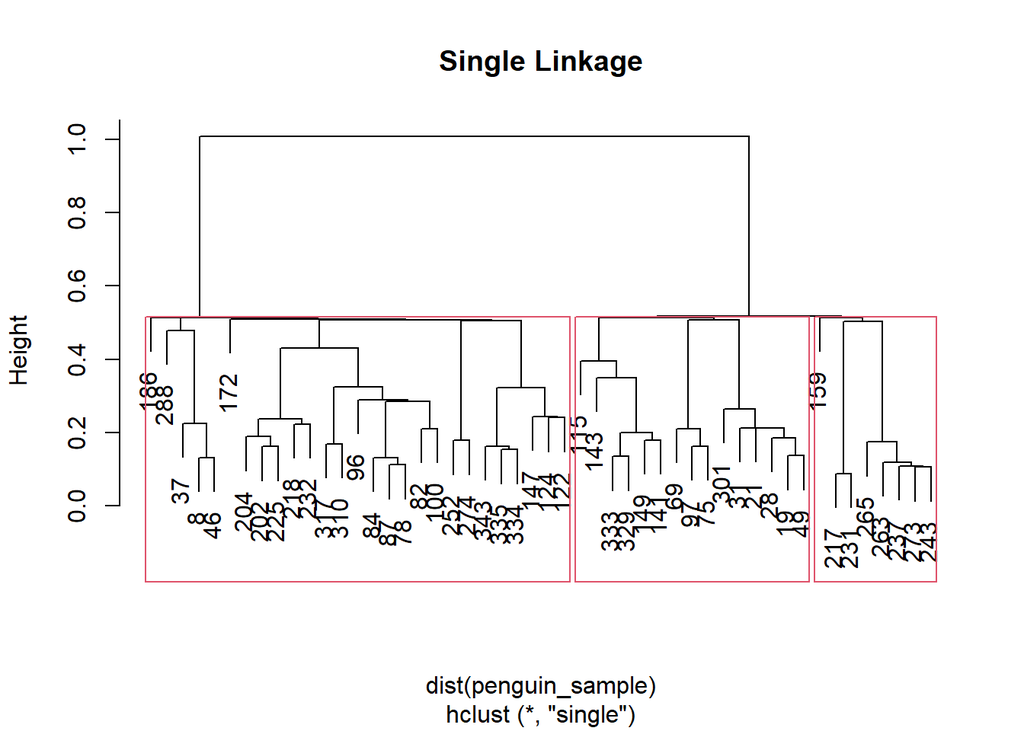

```r
set.seed(123)

# Single Linkage
hc_single <- hclust(dist(penguin_sample), method = "single")
plot(hc_single, main = "Single Linkage")
rect.hclust(hc_single,k=3)
```

```r
groups <- cutree(hc_single,k=3)
print(groups)
```

```
## 186  19 202 317 124 310 237 252 343 159  96  97 265 204 333 143  31   8 329 263
##   1   2   1   1   1   1   3   1   1   3   1   2   3   1   2   2   2   1   2   3
## 218  84  87  49 149  37 115 274  28 141 232 172 225 301  75  78  82  69 147 217
##   1   1   1   2   2   1   2   1   2   2   1   1   1   2   2   1   1   2   1   3
## 335 288  46 334 231  21 122 100 273 243
##   1   1   1   1   3   2   1   1   3   3
```